# 3.2 Linear Equations

## Linear Equations

- Should already have seen linear equations like \[y=mx+b\]
- In statistics, we write these as \[y=b_0 + b_1x\]
  - \(b_0\) and \(b_1\) are constants.
  - \(x\) is the **independent variable**.
  - \(y\) is the **dependent variable**

## Slope and Intercept

\[y=b_0 + b_1x\]

- The **y-intercept** is \(b_0\), the value of \(y\) when \(x=0\).
- The **slope** is \(b_1\), the change in \(y\) for a 1-unit change in \(x\).

A **scatterplot** shows the relationship between two (numeric) variables.

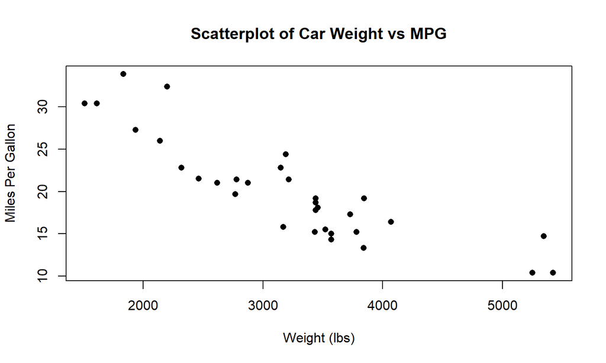

We call this type of data **bivariate data**.

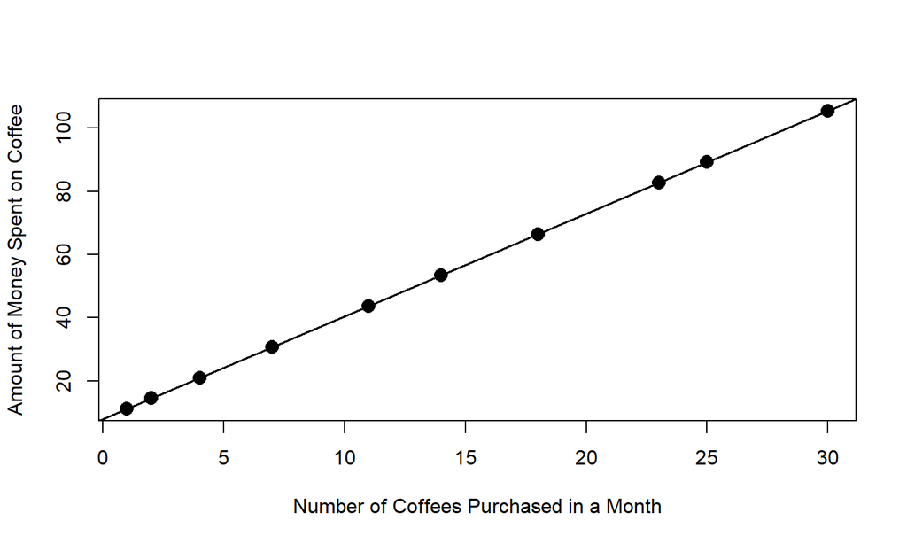

This relationship can be modeled perfectly with a straight line: \[y = 8 + 3.25x\]

- But what if that pound of coffee didn’t always cost $8?
- Or the coffee drinks didn’t always cost $3.25?

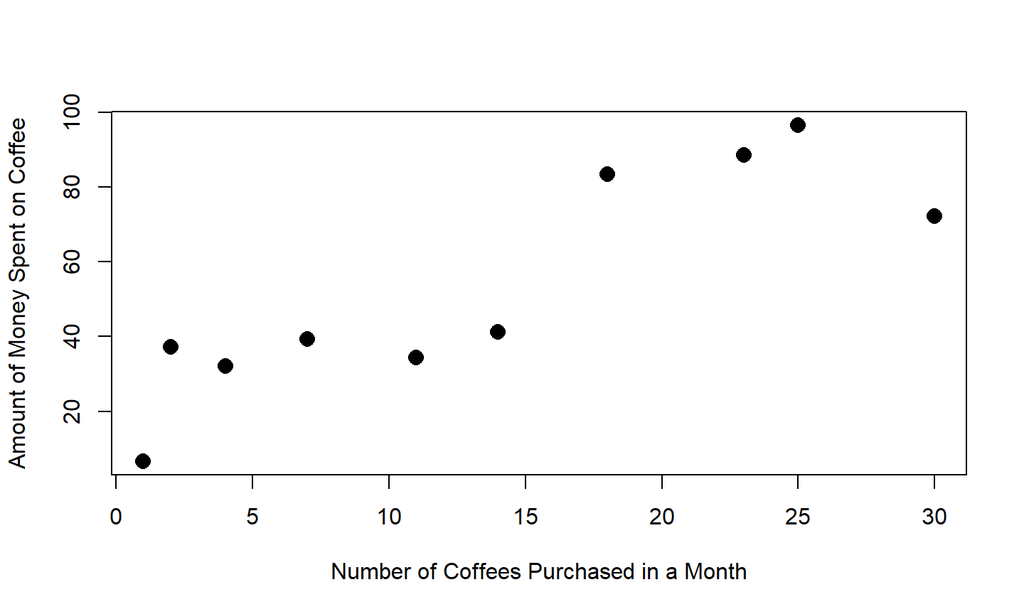

The linear regression line looks like \[y = \beta_0 + \beta_1x + \epsilon\]

- \(\beta\) is the Greek letter “beta”.
- \(\beta_0\) and \(\beta_1\) are constants.
- Error (the fact that the points don’t all line up perfectly) is represented by \(\epsilon\).

We estimate \(\beta_0\) and \(\beta_1\) using data and denote the estimated line by \[\hat{y} = b_0 + b_1x \]

- \(\hat{y}\), “y-hat”, is the estimated value of \(y\).
- \(b_0\) is the estimate for \(\beta_0\).
- \(b_1\) is the estimate for \(\beta_1\).

We use a regression line to make predictions about \(y\) using values of \(x\). Think of this as the 2-dimensional version of a point estimate!

- \(y\) is the **response variable**.
- \(x\) is the **predictor variable**.

## Example

*Example*: Researchers took a variety of measurements on 344 adult penguins in Antarctica.

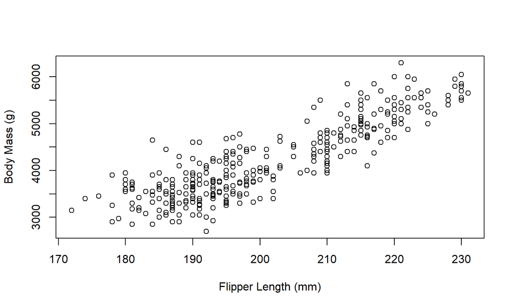

## Example

The regression model for these data is \[\hat{y}=-5780.83 + 49.69x\]

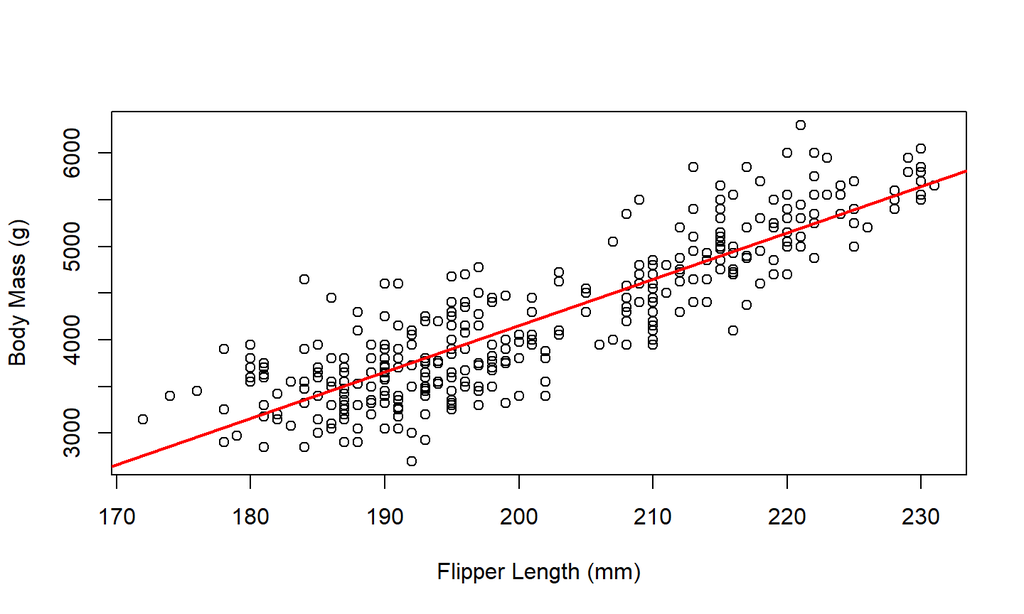